# Data Analyst Job Market Analysis

- Introduction
- Experience vs. Salary Analysis
- Salary Distribution by Programming Language
- Reflection on AI-Assisted Analysis Process

## Introduction

This report analyzes the current job market for Data Analyst positions, focusing on two key aspects: 1. The relationship between years of experience and salary expectations 2. How salary distributions vary across different programming language requirements

The analysis is based on 400 job postings, providing insights into current market trends and compensation patterns.

## Experience vs. Salary Analysis

The scatter plot below shows the relationship between minimum years of experience required and the median salary estimate for each position. This visualization helps identify whether there’s a clear correlation between experience requirements and compensation.

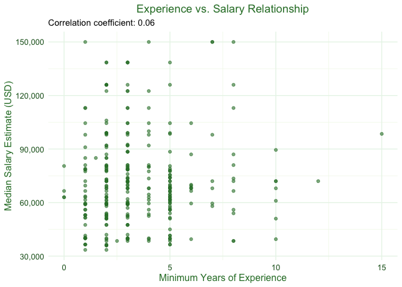

## Salary Distribution by Programming Language

The box plot below shows how salary distributions vary across different programming language requirements. This visualization helps identify which language requirements are associated with higher or lower salary ranges.

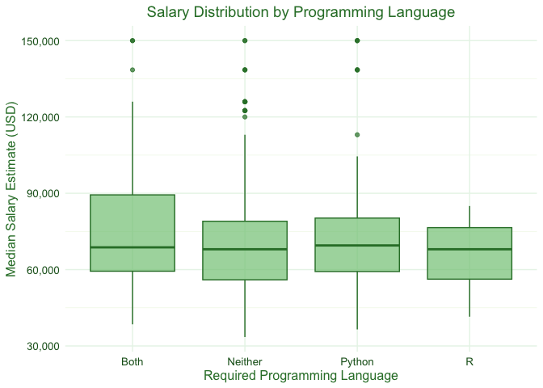

**Summary Statistics by Programming Language**

| Data Languages | Number of Jobs Count | Salary Statistics (USD) Mean_Salary | Salary Statistics (USD) Median_Salary | Salary Statistics (USD) SD_Salary |
| --- | --- | --- | --- | --- |
| Both | 64 | $76,875.00 | $68,750 | $25,871.02 |
| Python | 59 | $75,593.22 | $69,500 | $28,175.32 |
| Neither | 266 | $69,983.08 | $68,000 | $23,619.88 |
| R | 11 | $65,636.36 | $68,000 | $13,764.25 |

Note: Note: Salaries are rounded to the nearest dollar.

## Reflection on AI-Assisted Analysis Process

This report was created through an iterative process using AI assistance. The use of AI has considerably improved the dissemination of the analysis and supported the analysis process.

1. **Efficiency in Code Generation**:
   - The AI quickly generated the initial R code for data cleaning and visualization
   - Automated the creation of properly formatted R Markdown structure
   - Handled technical details like proper library imports and data type conversions
2. **Quality Control**:
   - The AI maintained consistent coding standards throughout the document
   - Ensured proper handling of missing values and data cleaning
   - Implemented best practices for visualization and table formatting
3. **Iterative Improvement**:
   - The report evolved through multiple iterations based on feedback incluidng improving the look of the html page
   - Each version improved upon the previous one in terms of clarity and presentation
   - The process demonstrated how AI can help refine and enhance data analysis
4. **Human-AI Collaboration**:
   - The AI handled technical implementation while allowing for human input on analysis direction
   - The process showed how AI can augment human analysis rather than replace it
   - The final report combines AI-generated code with human interpretation

This experience highlights how AI tools can streamline the data analysis process while maintaining high standards of quality and presentation. The iterative nature of the process, where the AI could quickly implement changes and improvements, demonstrates the potential for AI to enhance productivity in data analysis workflows. AI tools become more powerful the more you understand them. AI-assisted analysis can speed up routine tasks, but having coding skills lets you customize, refine, and extend those insights even further. That’s why I’ve decided to upskill my coding abilities and will join the R BoatCamp in July!